# NFL database

2023-09-21

During the scientific programming project I will do a statistical analysis on the performance of Quarterbacks(QB) in american football in the NFL(official national league of the US). I will look at what effect age has on performance and if there are significant differences in QB-play between generation. Furthermore, I will look at what stats across the entire offense are most important in determining how productive the offense is. Lastly, I will also create and evaluate a function that improves the current rating used to evaluate QB’s.

During a down, a lot of things can happen. QB can typically do one of 3 things. Throw the ball to Wide Receiver(WR) to attempt a pass, give the ball to the Runningback(RB) who will try to rush the ball forward, or rush the ball themselves. When the ball is thrown it can be intercepted by the defense of the opposing team. Furthermore whenever the QB gets tackled before getting the ball out it is called a sack. Lastly when any player on the field looses the ball it is called a fumble which can be recovered by both the defense and the offense. Based on these numbers, a scoring for each game is made by the NFL of the QB performance called passer rating.

The following code creates the passer rating. It incorporates successful passing percentage, yards per pass, touchdowns per pass and interceptions per pass. Scores are between 0 and 158.3

```r
#Create original passer rating function
calculate_passer_rating = function(COMP, ATT, YDS, TD, INT) {

  # Calculate the four components of the passer rating
  a = ((COMP / ATT) - 0.3) * 5
  b = ((YDS / ATT) - 3) * 0.25
  c = (TD / ATT) * 20
  d = 2.375 - ((INT / ATT) * 25)

  # Ensure that a,b,c&d are below 2.375 and above 0
  a = pmin(a, 2.375)
  a = pmax(a, 0)
  b = pmin(b, 2.375)
  b = pmax(b,0)
  c = pmin(c, 2.375)
  c = pmax(c,0)
  d = pmax(d, 0)

  # Calculate the passer rating
  passer_rating = ((a+b+c+d)/6) * 100


  return(passer_rating)
}
```

Since Passer rating does not include the entire skillset of a QB I have extended the function to include rushing, sacks and fumbles creating Passer rating2.0. Scores are more centered and are between 0 and 158.3 due to the fact that there are more variables that have to be minimized or maximized to create polarizing scores.

```r
#Create an improved passer rating function
calculate_passer_rating2.0 = function(COMP, ATT, YDS, TD, INT, SACK, S.YDS, RUSH, R.YDS, FUMB, FUMB.L) {
  # Calculate the seven components of the passer rating2.0
  a = ((COMP / ATT) - 0.3) * 5
  b = ((YDS / ATT) - 3) * 0.25
  c = (TD / ATT) * 20
  d = 2.375 - ((INT / ATT) * 25)
  e = ifelse(SACK == 0, 1.1875, 1.1875 - ((SACK / ATT) * (S.YDS / SACK)))
  f = ifelse(RUSH == 0, 0, ((R.YDS / RUSH) - 3) * 0.25)
  g = 2.375 - ((FUMB/ATT)*3 + (FUMB.L/ATT)*22)

  # Ensure that a,b,c & d are below 2.375, f is below 1.18875 and that everything is above 0
  a = pmin(a, 2.375)
  a = pmax(a, 0)
  b = pmin(b, 2.375)
  b = pmax(b,0)
  c = pmin(c, 2.375)
  c = pmax(c,0)
  d = pmax(d, 0)
  e = pmax(e, 0)
  f = pmin(f,1.1875)
  f = pmax(f,0)
  g = pmax(g,0)

  # Calculate the passer rating2.0
  passer_rating2.0 = ((a + b + c + d + e + f + g) / 9) * 100

  return(passer_rating2.0)
}
```

Underneath is a barchart that shows the distribution of passer rating scores

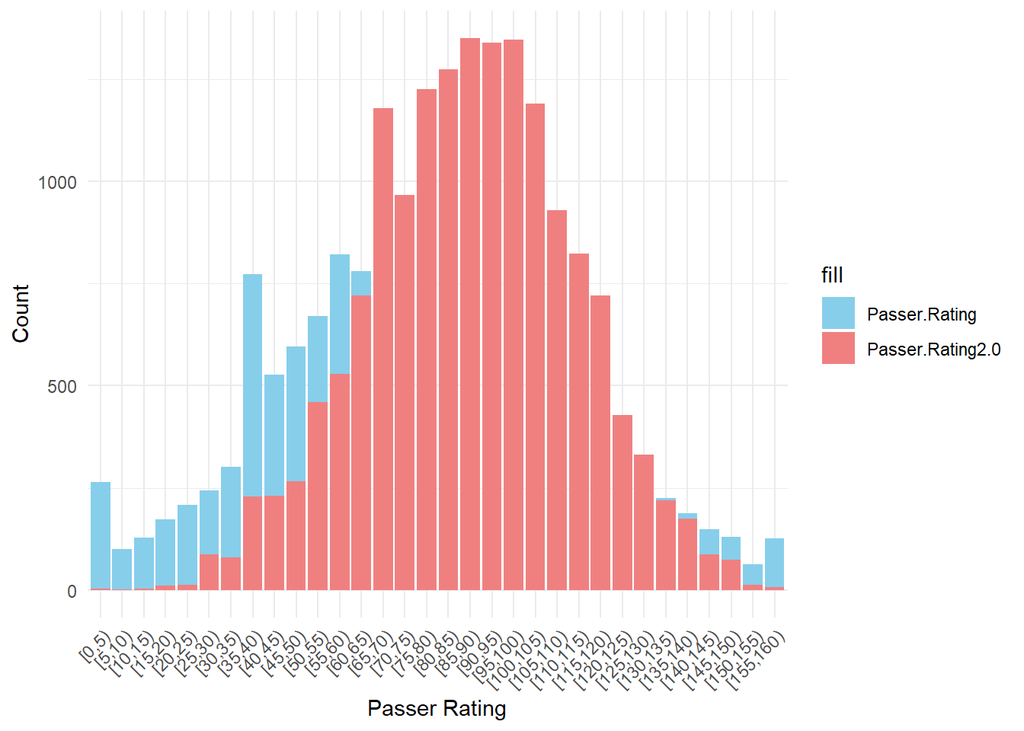

I perform an univariate regression on the full offensive performance to see which individual stat has the highest effect on offensive points. The results of the regression show which individual stat would be best to explain the variance in points scored by the offense. As expected, the Passer ratings have the highest scores with passer rating 2.0 slightly edging out the original passer rating

| IV | coefficient | intercept | p_value | adj_r2 |
| --- | --- | --- | --- | --- |
| QB_Passer.Rating2.0 | 0.290 | -4.672 | 0.0000000 | 0.378 |
| QB_Passer.Rating | 0.209 | 4.465 | 0.0000000 | 0.370 |
| QB_TD.Passes | 5.687 | 13.989 | 0.0000000 | 0.357 |
| K_Extra.Points.Made | 3.534 | 16.121 | 0.0000000 | 0.286 |
| K_Extra.Points.Attempted | 3.476 | 16.069 | 0.0000000 | 0.286 |
| WR_Receiving.TDs | 5.266 | 17.298 | 0.0000000 | 0.196 |
| RB_Rushing.TDs | 5.598 | 18.546 | 0.0000000 | 0.150 |
| QB_Passing.Yards | 0.039 | 12.950 | 0.0000000 | 0.110 |
| QB_Sacked.Yards.Lost | -0.226 | 24.357 | 0.0000000 | 0.085 |
| QB_Sacks | -1.700 | 24.623 | 0.0000000 | 0.082 |
| QB_Ints | -2.628 | 23.689 | 0.0000000 | 0.072 |
| RB_Rushing.Yards | 0.054 | 17.669 | 0.0000000 | 0.071 |
| WR_Receiving.Yards | 0.035 | 17.253 | 0.0000000 | 0.062 |
| RB_Rushing.Attempts | 0.207 | 17.852 | 0.0000000 | 0.044 |
| RB_Receiving.TDs | 5.674 | 20.429 | 0.0000000 | 0.031 |
| QB_Passes.Completed | 0.238 | 16.898 | 0.0000000 | 0.027 |
| WR_Receptions | 0.309 | 18.528 | 0.0000000 | 0.026 |
| K_FGs.Made | 1.389 | 19.786 | 0.0000000 | 0.023 |
| RB_Longest.Rushing.Run | 0.099 | 19.434 | 0.0000000 | 0.021 |
| QB_Rushing.TDs | 4.783 | 20.566 | 0.0000000 | 0.020 |
| K_Longest.FG.Made | 0.061 | 19.967 | 0.0000000 | 0.014 |
| K_FGs.Attempted | 0.798 | 20.096 | 0.0000000 | 0.011 |
| QB_Rushing.Attempts | 0.429 | 19.961 | 0.0000000 | 0.008 |
| QB_Fumbles | -1.301 | 21.473 | 0.0000000 | 0.007 |
| RB_Receiving.Yards | 0.032 | 20.238 | 0.0000000 | 0.007 |
| WR_Longest.Reception | 0.028 | 19.888 | 0.0000000 | 0.007 |
| WR_Rushing.Yards | 0.134 | 20.807 | 0.0000000 | 0.007 |
| WR_Longest.Rushing.Run | 0.175 | 20.820 | 0.0000000 | 0.006 |
| QB_Fumbles.Lost | -1.841 | 21.283 | 0.0000000 | 0.005 |
| QB_Age | 0.188 | 15.624 | 0.0000000 | 0.005 |
| RB_Longest.Reception | 0.056 | 20.368 | 0.0000000 | 0.005 |
| WR_Rushing.Attempts | 0.692 | 20.834 | 0.0000000 | 0.003 |
| WR_Rushing.TDs | 7.086 | 20.957 | 0.0000000 | 0.003 |
| QB_Passes.Attempted | -0.010 | 21.295 | 0.2413305 | 0.000 |
| QB_Rushing.Yards | 0.001 | 20.998 | 0.8001957 | 0.000 |
| RB_Receptions | 0.072 | 20.802 | 0.0221106 | 0.000 |
| RB_Fumbles | 0.317 | 20.966 | 0.1365032 | 0.000 |
| RB_Fumbles.Lost | -0.139 | 21.023 | 0.6326820 | 0.000 |
| WR_Fumbles | -0.053 | 21.018 | 0.8336194 | 0.000 |
| WR_Fumbles.Lost | -0.599 | 21.045 | 0.0931885 | 0.000 |
| K_Kicks.Blocked | -0.203 | 21.016 | 0.7382748 | 0.000 |

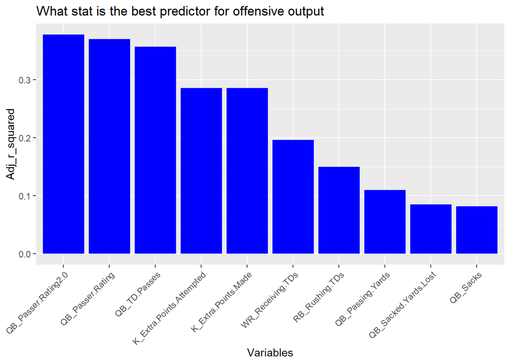

| IV | Coefficient | P_Value | adj_r2 | Part_R_Squared |
| --- | --- | --- | --- | --- |
| RB_Rushing.TDs | 4.659 | 0.0000000 | 0.697 | 0.058 |
| QB_TD.Passes | 3.685 | 0.0000000 | 0.697 | 0.031 |
| K_FGs.Made | 3.671 | 0.0000000 | 0.697 | 0.018 |
| QB_Rushing.TDs | 4.538 | 0.0000000 | 0.697 | 0.014 |
| K_FGs.Attempted | -1.708 | 0.0000000 | 0.697 | 0.006 |
| QB_Passes.Attempted | -0.234 | 0.0000000 | 0.697 | 0.004 |
| K_Longest.FG.Made | -0.068 | 0.0000000 | 0.697 | 0.004 |
| QB_Passing.Yards | 0.022 | 0.0000000 | 0.697 | 0.002 |
| WR_Receiving.TDs | 1.019 | 0.0000000 | 0.697 | 0.002 |
| RB_Rushing.Attempts | -0.109 | 0.0000000 | 0.697 | 0.001 |
| WR_Rushing.TDs | 5.802 | 0.0000000 | 0.697 | 0.001 |
| QB_Ints | -0.560 | 0.0000000 | 0.697 | 0.000 |
| QB_Sacks | -0.357 | 0.0000001 | 0.697 | 0.000 |
| QB_Age | 0.052 | 0.0000331 | 0.697 | 0.000 |
| RB_Rushing.Yards | 0.016 | 0.0000000 | 0.697 | 0.000 |
| RB_Receptions | -0.194 | 0.0000006 | 0.697 | 0.000 |
| RB_Receiving.TDs | 1.017 | 0.0000000 | 0.697 | 0.000 |
| K_Extra.Points.Made | 1.172 | 0.0000013 | 0.697 | 0.000 |
| QB_Passes.Completed | 0.072 | 0.0086475 | 0.697 | -0.001 |
| QB_Sacked.Yards.Lost | -0.031 | 0.0009410 | 0.697 | -0.001 |
| QB_Rushing.Attempts | 0.044 | 0.2031325 | 0.697 | -0.001 |
| QB_Rushing.Yards | -0.020 | 0.0014598 | 0.697 | -0.001 |
| QB_Fumbles | -0.057 | 0.5778122 | 0.697 | -0.001 |
| QB_Fumbles.Lost | -0.024 | 0.9023506 | 0.697 | -0.001 |
| RB_Longest.Rushing.Run | -0.006 | 0.1828050 | 0.697 | -0.001 |
| RB_Receiving.Yards | 0.006 | 0.2043129 | 0.697 | -0.001 |
| RB_Longest.Reception | -0.006 | 0.3143049 | 0.697 | -0.001 |
| RB_Fumbles | -0.374 | 0.0457074 | 0.697 | -0.001 |
| RB_Fumbles.Lost | -0.493 | 0.0509507 | 0.697 | -0.001 |
| WR_Receptions | -0.083 | 0.0037083 | 0.697 | -0.001 |
| WR_Receiving.Yards | 0.001 | 0.5215948 | 0.697 | -0.001 |
| WR_Longest.Reception | 0.001 | 0.7556943 | 0.697 | -0.001 |
| WR_Rushing.Attempts | -0.084 | 0.2718185 | 0.697 | -0.001 |
| WR_Rushing.Yards | -0.009 | 0.5835040 | 0.697 | -0.001 |
| WR_Longest.Rushing.Run | 0.059 | 0.0031609 | 0.697 | -0.001 |
| WR_Fumbles | -0.175 | 0.4003011 | 0.697 | -0.001 |
| WR_Fumbles.Lost | -0.708 | 0.0156826 | 0.697 | -0.001 |
| K_Kicks.Blocked | 0.368 | 0.2916982 | 0.697 | -0.001 |
| K_Extra.Points.Attempted | 0.113 | 0.6376127 | 0.697 | -0.001 |
| QB_Passer.Rating | -0.005 | 0.5646250 | 0.697 | -0.001 |
| QB_Passer.Rating2.0 | 0.037 | 0.0034666 | 0.697 | -0.001 |

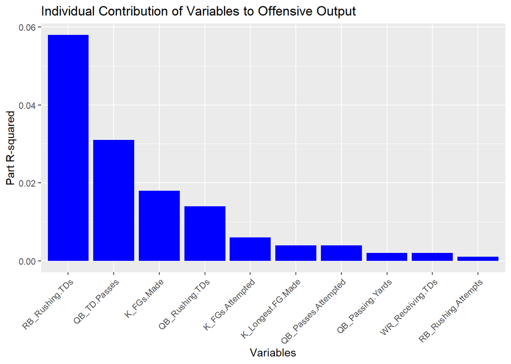

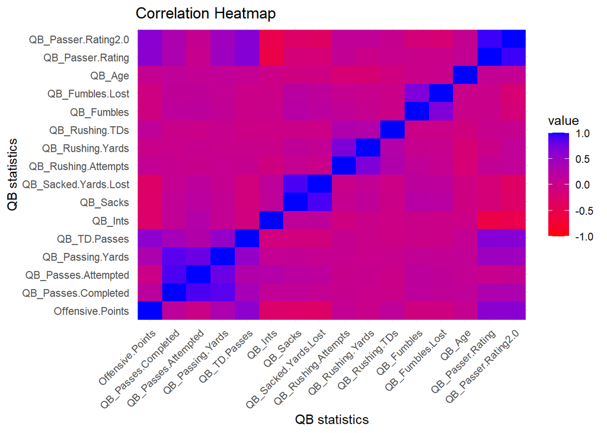

Another question that I wanted to investigate was how age effects QB play. Therefore I’ve created a comparison of some of the most important variables of QB play.

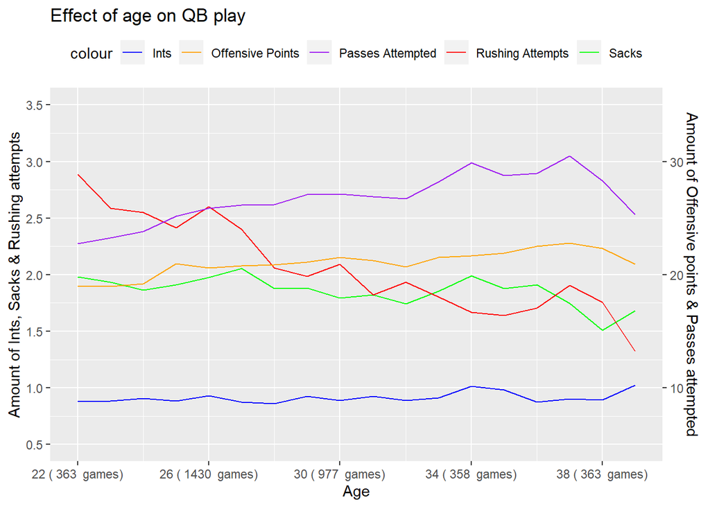

| DV | intercept | coefficient | p_value | adj_r2 |
| --- | --- | --- | --- | --- |
| QB_Rushing.Attempts | 5.226 | -0.097 | 0.0000000 | 0.032 |
| QB_Passes.Attempted | 22.362 | 0.252 | 0.0000000 | 0.009 |
| Offensive.Points | 15.624 | 0.188 | 0.0000000 | 0.005 |
| QB_Sacks | 2.794 | -0.023 | 0.0000000 | 0.003 |
| QB_Ints | 1.138 | -0.004 | 0.0619349 | 0.000 |

What we can gather from this data is that aging quarterbacks typically tend to get better over time creating more offensive output per game. They do this by an increase of their passing attempts and a decrease in their rushing attempts. This can be explained by the risk of injury that rushing attempts have which does not suit an older QB and the increase of experience that a older QB has to oversee the play and see free wide receivers

Furthermore, I was interested in which QB’s have been the most successful over their entire career. Therefore, I’ve created the following scatter plot which compares passer rating to win percentage

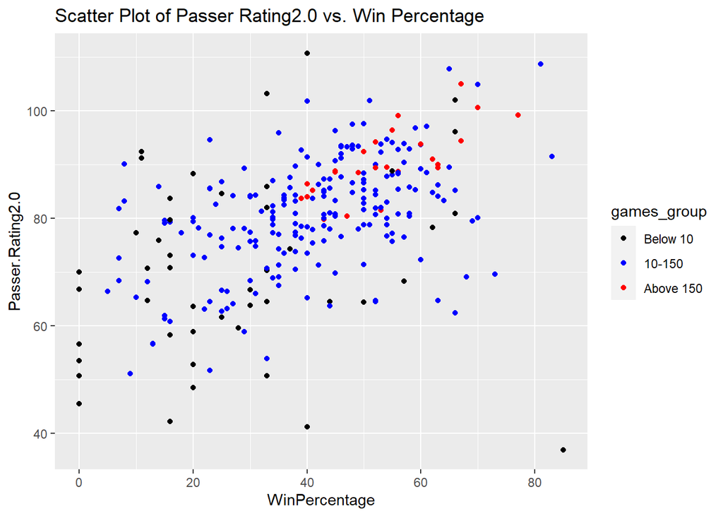

| Name | WinPercentage | Passer.Rating2.0 | Amount_of_games |
| --- | --- | --- | --- |
| Rodgers, Aaron | 65 | 107.87040 | 141 |
| Young, Steve | 67 | 105.02671 | 161 |
| Wilson, Russell | 70 | 104.88301 | 80 |
| Manning, Peyton | 70 | 100.58013 | 266 |
| Brady, Tom | 77 | 99.19950 | 237 |
| Luck, Andrew | 61 | 97.09699 | 70 |
| Roethlisberger, Ben | 67 | 94.44398 | 185 |
| Favre, Brett | 62 | 91.00333 | 301 |
| Kelly, Jim | 63 | 90.04612 | 160 |

Finally, I have performed a PCA to see if there are any characteristics that can clearly seperate QB’s I have used the QB passer stats as well as sacks, offensive points, rumbles and rushing to base the PCA on. In the PCA the games are color coded for the generation in which the player has played, how many games they have played and their average passer rating.

```
## Importance of components:
##                           PC1    PC2    PC3    PC4     PC5     PC6     PC7
## Standard deviation     1.9644 1.2223 1.1003 0.8139 0.61920 0.52197 0.32876
## Proportion of Variance 0.4824 0.1867 0.1513 0.0828 0.04793 0.03406 0.01351
## Cumulative Proportion  0.4824 0.6691 0.8204 0.9032 0.95116 0.98521 0.99872
##                            PC8
## Standard deviation     0.10102
## Proportion of Variance 0.00128
## Cumulative Proportion  1.00000
```

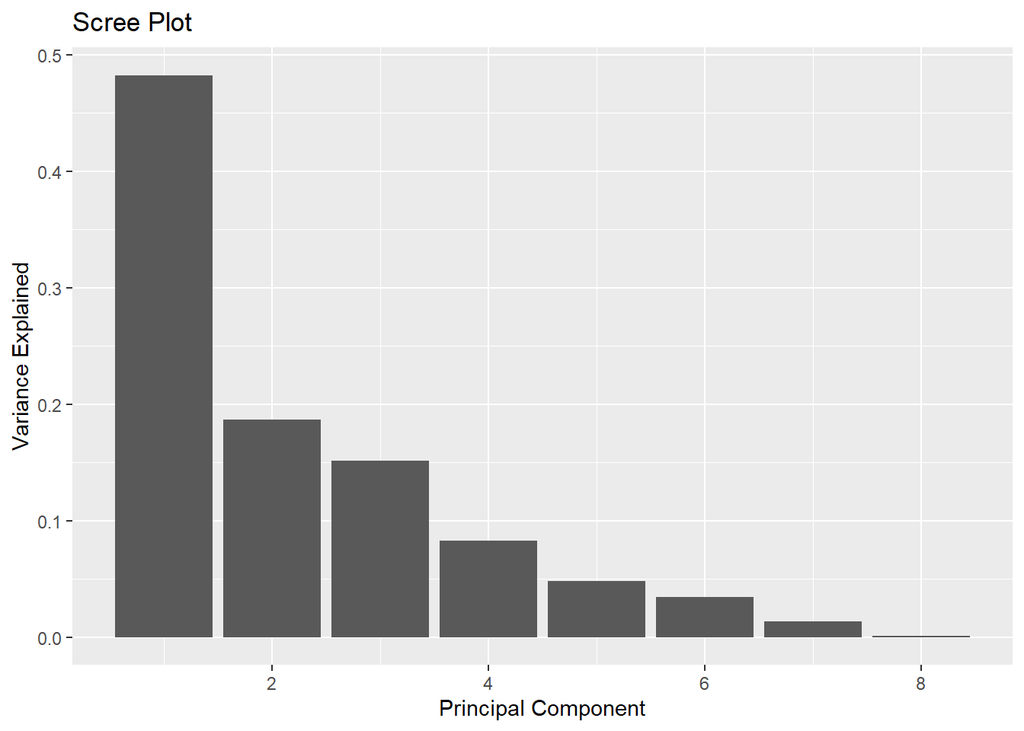

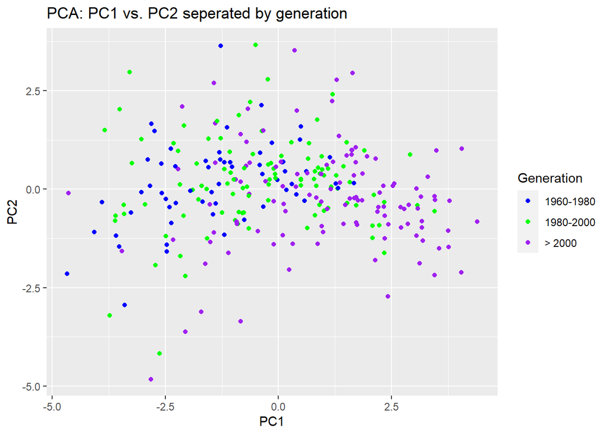

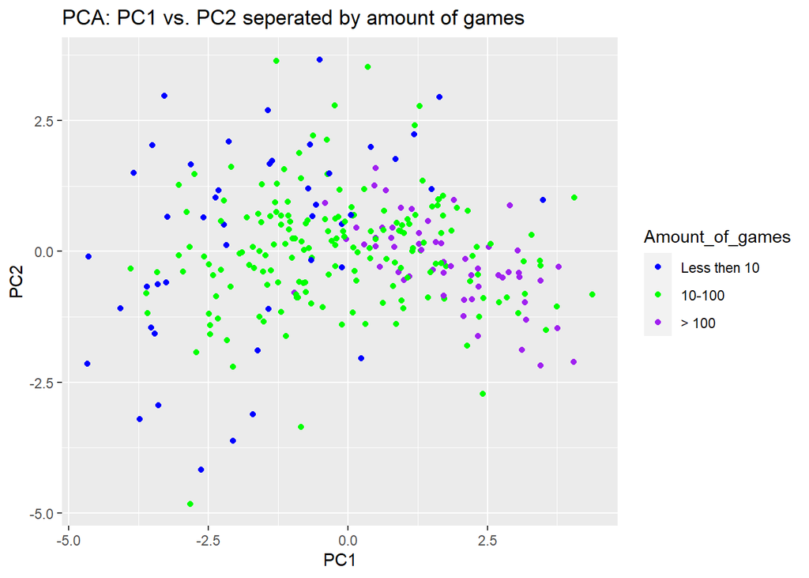

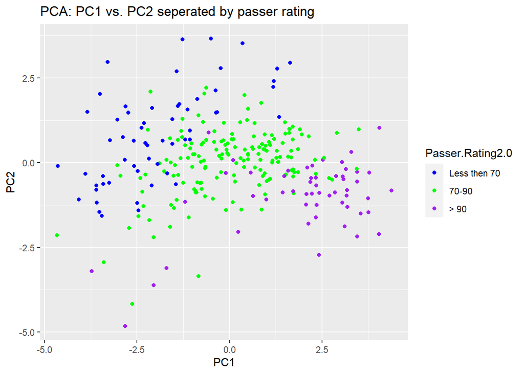

Overall, the results don’t show a clear separation in games between generations. What it does show is a clear gradient based on the amount of games played as well as the passer rating. The Passer rating result is slightly biased since the variables on which passer rating are based can also be found in the PCA analysis. However it is interesting to see that amount of games, specifically players in the >100 group are separated from the other players. This agrees with the previously found results that also saw that more experienced players typically tend to play better than their less experienced counterparts